# Project 4 - Evaluate Oregon Contributions

# Final Evaluation Graphs

These charts are the final charts showing more detailed analysis

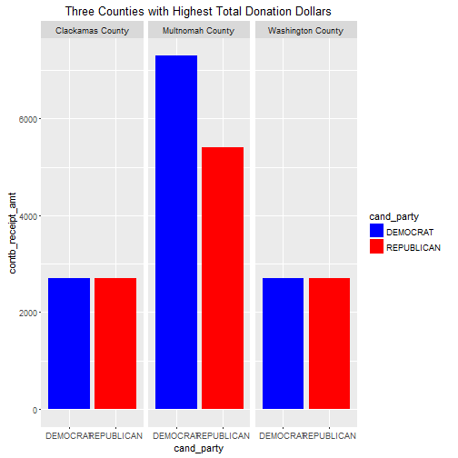

```r
#And now those three top counties by the top candidates.
#Lets look at these counties by party, I would expect to find a lean towards
#democrat especially in Multnomah county
p9a <- ggplot(aes(x = cand_party,  y = contb_receipt_amt, fill = cand_party),
              data = subset(cont_lead_counties, contb_receipt_amt > 0)) +
  facet_wrap( ~ county) +
    scale_fill_manual(values=party_color) +
  geom_bar(stat = "identity", position = "identity") +
  ggtitle("Three Counties with Highest Total Donation Dollars")
p9a
```

```r
#As expected there is more money coming in from Multnomah County compared
#to any of the others.  It is suprising for an area so often considered
#Blue that there is still considerable Republican donations.
```

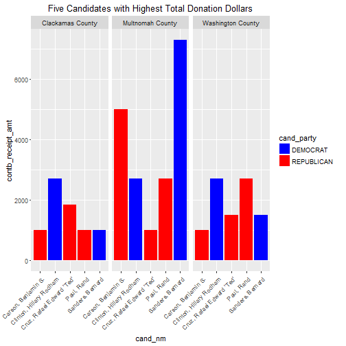

```r
#Graph showing the same three counties, divided by candidate and
#indicating parties.

p9b <- ggplot(aes(x = cand_nm,  y = contb_receipt_amt, fill = cand_party),
              data = subset(lead_counties_five, contb_receipt_amt > 0)) +
  facet_wrap( ~ county) +
    scale_fill_manual(values=party_color) +
  geom_bar(stat = "identity", position = "identity") +
  theme(axis.text.x = element_text(angle = 45, hjust = 1)) +
  ggtitle("Five Candidates with Highest Total Donation Dollars")
p9b
```

```r
#Rather intersting how much support that Carson has in Multnomah county.
#Considering how "Blue" the area is thought of I am suprised to see so much
#support for Carson.
```

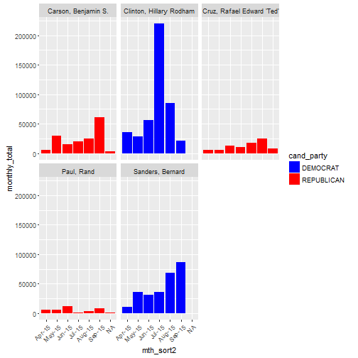

```r
#
top_five_only <- subset(cont_table.fc_by_summarize, cand_nm == "Sanders, Bernard" |
                    cand_nm == "Carson, Benjamin S." |
                    cand_nm == "Clinton, Hillary Rodham" |
                    cand_nm == "Cruz, Rafael Edward 'Ted'" |
                    cand_nm == "Paul, Rand")

mth_sort2 = factor(top_five_only$mth_yr, levels = c("Apr-15","May-15","Jun-15","Jul-15","Aug-15","Sep-15"))

p9c <- ggplot(aes(x = mth_sort2, y = monthly_total, fill = cand_party),
              data = subset(top_five_only)) +
  facet_wrap( ~ cand_nm) +
  scale_fill_manual(values = party_color) +
  geom_bar(stat = "identity", position = "identity") +
  theme(axis.text.x = element_text(angle = 45, hjust = 1))
p9c
```

## Reflection

Oregon has long been a Blue State when it comes to the Presidential elections, so finding that the Democratic Candidates had a greater support base was not unexpected. I was also unsurprised to see that the top counties and zip codes are those that make up and surround the Portland area as it is the most population dense. It was interesting to see that even in these urban areas there was still a strong showing for Republican candidates, which I found to be unexpected. Overall the information presented matched expected results and was an interesting peak into the financial side of the election.